# Graded Microproject_Varshini Sree J K

Name : Varshini Sree J K

Email Id: varshinisree2408@gmail.com

```python
#Import the libraries

import pandas as pd
import numpy as np
import matplotlib.pyplot as plt
%matplotlib inline
import seaborn as sns

import math
import statistics as stt
import scipy.stats as stats
import missingno as ms

import warnings
warnings.filterwarnings("ignore")
```

## EDA on a finance company that provides car loan

```python
df = pd.read_excel('car_loan.xlsx',sheet_name=[0,1])
```

```python
x = df[0]
y = df[1]
df1 = pd.concat([x,y], axis=1)
df1.head()
```

|  | cust.ID | Amount.Requested for loan | Amount.Funded.By.Investors to bank | Interest.Rate | Loan duration | cust.ID | Family_incomeIncome | credit_score | Employment.Length | owning a two wheeler |
| --- | --- | --- | --- | --- | --- | --- | --- | --- | --- | --- |
| 0 | 84563.0 | 8000 | 8000 | 7.62# | 36 months | 84563.0 | 3500 | 765-769 | NaN | yes |
| 1 | 78765.0 | 9000 | 9000 | 10.16# | 36 months | 78765.0 | 5166.67 | 710-714 | 10 + years | no |
| 2 | 24590.0 | 13000 | 12975 | 9.99# | 60 months | 24590.0 | 10500 | 800-804 | 10+ years | yes |
| 3 | 9061.0 | 10000 | 10000 | 14.22# | 36 months | 9061.0 | 2541.67 | 680-684 | 8 years | no |
| 4 | 47011.0 | 3600 | 3600 | 13.67# | 36 months | 47011.0 | 5113 | 690-694 | NaN | yes |

#### Renaming column names for easy access

```python
df1.columns=['cust_ID', 'Amount_Requested_for_loan',
       'Amount_Funded_By_Investors', 'Interest_Rate', 'Loan_duration', '"cust.ID',
       'Family_income', 'credit_score', 'Employment_Length', 'Owning_two_wheeler']
```

```python
df1.head()
```

|  | cust_ID | Amount_Requested_for_loan | Amount_Funded_By_Investors | Interest_Rate | Loan_duration | "cust.ID | Family_income | credit_score | Employment_Length | Owning_two_wheeler |
| --- | --- | --- | --- | --- | --- | --- | --- | --- | --- | --- |
| 0 | 84563.0 | 8000 | 8000 | 7.62# | 36 months | 84563.0 | 3500 | 765-769 | NaN | yes |
| 1 | 78765.0 | 9000 | 9000 | 10.16# | 36 months | 78765.0 | 5166.67 | 710-714 | 10 + years | no |
| 2 | 24590.0 | 13000 | 12975 | 9.99# | 60 months | 24590.0 | 10500 | 800-804 | 10+ years | yes |
| 3 | 9061.0 | 10000 | 10000 | 14.22# | 36 months | 9061.0 | 2541.67 | 680-684 | 8 years | no |
| 4 | 47011.0 | 3600 | 3600 | 13.67# | 36 months | 47011.0 | 5113 | 690-694 | NaN | yes |

```python
df2 = pd.read_csv('age_band.csv',sep='\\t',error_bad_lines=False)
df2.head()
```

|  | "cust.ID | age-band | Debt.To.Income.Ratio", |
| --- | --- | --- | --- |
| 0 | "84563 | 25-39 | 0!", |
| 1 | "78765 | 25-40 | 13.76!", |
| 2 | "24590 | 25-41 | 8.77!", |
| 3 | "9061 | 25-42 | 12.24!", |
| 4 | "47011 | 25-43 | 16.41!", |

### Merging 'car_loan.xlsx' and 'age_band.csv' as one file and storing it in df3

```python
df3 = pd.concat([df1,df2], axis=1)
df3.head()
```

|  | cust_ID | Amount_Requested_for_loan | Amount_Funded_By_Investors | Interest_Rate | Loan_duration | "cust.ID | Family_income | credit_score | Employment_Length | Owning_two_wheeler | "cust.ID | age-band | Debt.To.Income.Ratio", |
| --- | --- | --- | --- | --- | --- | --- | --- | --- | --- | --- | --- | --- | --- |
| 0 | 84563.0 | 8000 | 8000 | 7.62# | 36 months | 84563.0 | 3500 | 765-769 | NaN | yes | "84563 | 25-39 | 0!", |
| 1 | 78765.0 | 9000 | 9000 | 10.16# | 36 months | 78765.0 | 5166.67 | 710-714 | 10 + years | no | "78765 | 25-40 | 13.76!", |
| 2 | 24590.0 | 13000 | 12975 | 9.99# | 60 months | 24590.0 | 10500 | 800-804 | 10+ years | yes | "24590 | 25-41 | 8.77!", |
| 3 | 9061.0 | 10000 | 10000 | 14.22# | 36 months | 9061.0 | 2541.67 | 680-684 | 8 years | no | "9061 | 25-42 | 12.24!", |
| 4 | 47011.0 | 3600 | 3600 | 13.67# | 36 months | 47011.0 | 5113 | 690-694 | NaN | yes | "47011 | 25-43 | 16.41!", |

```python
df3.shape  ## 2186Rows, 13 columns
```

```
(2186, 13)
```

### PART 1

1. I) Check for duplicate columns & remove them

```python
duplicates = df3.columns[df3.columns.duplicated()]
print("The duplicate column in the dataset is:", duplicates)

df3 = df3.loc[:,~df3.columns.duplicated()]
df3.head()
```

```
The duplicate column in the dataset is: Index(['"cust.ID'], dtype='object')
```

|  | cust_ID | Amount_Requested_for_loan | Amount_Funded_By_Investors | Interest_Rate | Loan_duration | "cust.ID | Family_income | credit_score | Employment_Length | Owning_two_wheeler | age-band | Debt.To.Income.Ratio", |
| --- | --- | --- | --- | --- | --- | --- | --- | --- | --- | --- | --- | --- |
| 0 | 84563.0 | 8000 | 8000 | 7.62# | 36 months | 84563.0 | 3500 | 765-769 | NaN | yes | 25-39 | 0!", |
| 1 | 78765.0 | 9000 | 9000 | 10.16# | 36 months | 78765.0 | 5166.67 | 710-714 | 10 + years | no | 25-40 | 13.76!", |
| 2 | 24590.0 | 13000 | 12975 | 9.99# | 60 months | 24590.0 | 10500 | 800-804 | 10+ years | yes | 25-41 | 8.77!", |
| 3 | 9061.0 | 10000 | 10000 | 14.22# | 36 months | 9061.0 | 2541.67 | 680-684 | 8 years | no | 25-42 | 12.24!", |
| 4 | 47011.0 | 3600 | 3600 | 13.67# | 36 months | 47011.0 | 5113 | 690-694 | NaN | yes | 25-43 | 16.41!", |

II) If you want you can drop column/columns (Mention the reason for the same for removing or not)

```python
df3 = df3.drop('"cust.ID', axis=1)
```

```python
df3.shape
```

```
(2186, 11)
```

#### Renaming column names for easy access

```python
df3.columns=['cust_ID', 'Amount_Requested_for_loan',
       'Amount_Funded_By_Investors', 'Interest_Rate', 'Loan_duration',
       'Family_income', 'credit_score', 'Employment_Length',
       'owning_two_wheeler', 'age_band', 'Debt_To_Income_Ratio']
```

```python
df3.head()
```

|  | cust_ID | Amount_Requested_for_loan | Amount_Funded_By_Investors | Interest_Rate | Loan_duration | Family_income | credit_score | Employment_Length | owning_two_wheeler | age_band | Debt_To_Income_Ratio |
| --- | --- | --- | --- | --- | --- | --- | --- | --- | --- | --- | --- |
| 0 | 84563.0 | 8000 | 8000 | 7.62# | 36 months | 3500 | 765-769 | NaN | yes | 25-39 | 0!", |
| 1 | 78765.0 | 9000 | 9000 | 10.16# | 36 months | 5166.67 | 710-714 | 10 + years | no | 25-40 | 13.76!", |
| 2 | 24590.0 | 13000 | 12975 | 9.99# | 60 months | 10500 | 800-804 | 10+ years | yes | 25-41 | 8.77!", |
| 3 | 9061.0 | 10000 | 10000 | 14.22# | 36 months | 2541.67 | 680-684 | 8 years | no | 25-42 | 12.24!", |
| 4 | 47011.0 | 3600 | 3600 | 13.67# | 36 months | 5113 | 690-694 | NaN | yes | 25-43 | 16.41!", |

#### Inference:

Customer Id is column which is repeated. Hence, I have dropped it

### 2. Using seaborn/matplotlib give any two visuals and mention the insights.

#### Inference:

1.cust.ID is the only column in the dataset that is of float datatype.

2.since majority of the columns are of 'object' datatype it would be difficult to visualize and interpret the results

3.Datatype conversion is necessary inorder to perform visualization as it requires the columns to be with proper data set inorder to give efficient output

### 3. Clean the data (string cleaning)

```python
df3.head()
```

|  | cust_ID | Amount_Requested_for_loan | Amount_Funded_By_Investors | Interest_Rate | Loan_duration | Family_income | credit_score | Employment_Length | owning_two_wheeler | age_band | Debt_To_Income_Ratio |
| --- | --- | --- | --- | --- | --- | --- | --- | --- | --- | --- | --- |
| 0 | 84563.0 | 8000 | 8000 | 7.62# | 36 months | 3500 | 765-769 | NaN | yes | 25-39 | 0!", |
| 1 | 78765.0 | 9000 | 9000 | 10.16# | 36 months | 5166.67 | 710-714 | 10 + years | no | 25-40 | 13.76!", |
| 2 | 24590.0 | 13000 | 12975 | 9.99# | 60 months | 10500 | 800-804 | 10+ years | yes | 25-41 | 8.77!", |
| 3 | 9061.0 | 10000 | 10000 | 14.22# | 36 months | 2541.67 | 680-684 | 8 years | no | 25-42 | 12.24!", |
| 4 | 47011.0 | 3600 | 3600 | 13.67# | 36 months | 5113 | 690-694 | NaN | yes | 25-43 | 16.41!", |

```python
#Converting 'Amount_Requested_for_loan', 'Amount_Funded_By_Investors', 'Family_income' to float
for col in ['Amount_Requested_for_loan', 'Amount_Funded_By_Investors', 'Family_income']:
    df3[col]=pd.to_numeric(df3[col], errors = 'coerce')

# Remove '#' symbol from 'Interest.Rate' and convert to float
df3['Interest_Rate'] = df3['Interest_Rate'].astype(str)
df3['Interest_Rate'] = df3['Interest_Rate'].str.replace('[^\d]', '', regex=True).astype(float)
```

```python
# converting 'Debt.To.Income.Ratio' by removing non-numeric characters and by changing to float
df3['Debt_To_Income_Ratio']=df3['Debt_To_Income_Ratio'].str.replace('!"','')
df3['Debt_To_Income_Ratio']=df3.Debt_To_Income_Ratio.str.replace(',','')
df3['Debt_To_Income_Ratio'] = pd.to_numeric(df3['Debt_To_Income_Ratio'], errors='coerce')
```

```python
#Removing unwanted characters from 'credit_score' and converting it to int data type
df3['credit_score'] = df3['credit_score'].apply(lambda x: None if x is None else (sum(map(int, str(x).replace('!', '').split('-'))) / 2) if '-' in str(x) else None)
df3['credit_score'] = df3['credit_score'].astype(int)
```

```python
#Removing unwanted characters from 'Loan_duration' and converting it from object data type to float
df3['Loan_duration'] = df3['Loan_duration'].str.replace(' months', '').str.replace('>= ', '')
df3['Loan_duration']=df3.Loan_duration.str.replace(' 36','36')
```

```python
# Removing unwanted characters from 'owning_two_wheeler' column
df3['owning_two_wheeler']=df3.owning_two_wheeler.str.replace(' !','')
df3['owning_two_wheeler']=df3.owning_two_wheeler.str.replace('!','yes')
df3['owning_two_wheeler']=df3.owning_two_wheeler.str.replace('yes ','yes')
df3['owning_two_wheeler']=df3.owning_two_wheeler.str.replace('noo','no')
df3['owning_two_wheeler']=df3.owning_two_wheeler.str.replace('noo','no')
```

```python
#Removing unwanted characters from 'age_band' column
df3['age_band']=df3.age_band.str.replace('"','')
df3['age_band']=df3.age_band.str.replace(',','-')
df3['age_band']=df3.age_band.str.replace('!','')
```

```python
# Removing unwanted characters from 'Employment_Length'
df3['Employment_Length'] = df3['Employment_Length'].str.replace('[^\d.]', '', regex=True)

# Converting the 'Employment_Length' from object to float
df3['Employment_Length'] = pd.to_numeric(df3['Employment_Length'], errors='coerce')
```

```python
df3.dtypes
```

```
cust_ID                       float64
Amount_Requested_for_loan     float64
Amount_Funded_By_Investors    float64
Interest_Rate                 float64
Loan_duration                  object
Family_income                 float64
credit_score                    int32
Employment_Length             float64
owning_two_wheeler             object
age_band                       object
Debt_To_Income_Ratio          float64
dtype: object
```

```python
df3.head()
```

|  | cust_ID | Amount_Requested_for_loan | Amount_Funded_By_Investors | Interest_Rate | Loan_duration | Family_income | credit_score | Employment_Length | owning_two_wheeler | age_band | Debt_To_Income_Ratio |
| --- | --- | --- | --- | --- | --- | --- | --- | --- | --- | --- | --- |
| 0 | 84563.0 | 8000.0 | 8000.0 | 762.0 | 36 | 3500.00 | 767 | NaN | yes | 25-39 | 0.00 |
| 1 | 78765.0 | 9000.0 | 9000.0 | 1016.0 | 36 | 5166.67 | 712 | 10.0 | no | 25-40 | 13.76 |
| 2 | 24590.0 | 13000.0 | 12975.0 | 999.0 | 60 | 10500.00 | 802 | 10.0 | yes | 25-41 | 8.77 |
| 3 | 9061.0 | 10000.0 | 10000.0 | 1422.0 | 36 | 2541.67 | 682 | 8.0 | no | 25-42 | 12.24 |
| 4 | 47011.0 | 3600.0 | 3600.0 | 1367.0 | 36 | 5113.00 | 692 | NaN | yes | 25-43 | 16.41 |

2.Using seaborn/matplotlib give any two visuals and mention the insights.

#### Distribution of Credit Score using Histogram

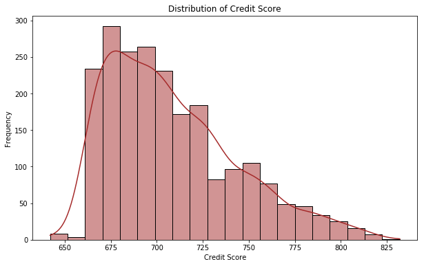

```python
plt.figure(figsize=(10,6))
sns.histplot(df3['credit_score'], bins=20, kde=True, color='brown')
plt.xlabel('Credit Score')
plt.ylabel('Frequency')
plt.title('Distribution of Credit Score')
plt.show()
```

### Inference:

1. The peak value of credit score is observed between 675-680 which depicts that considerable amount of applicants have credit score between this range.
2. Decrease in frequency is observed in the credit score distribution as the value gradually moves away from the peak which concludes that there are only few people who have higher credit scores such as 825.

## Correlation Heatmap

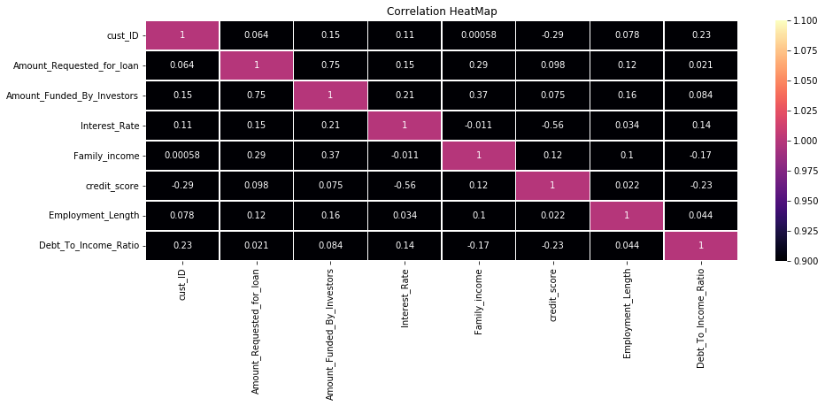

```python
plt.figure(figsize=(15, 5))
sns.heatmap(df3.corr(), annot=True,  vmin=1, vmax=1, cmap='magma', linewidths=0.5)
plt.title('Correlation HeatMap')
plt.show()
```

#### Inference:

1.A correlation coefficient of 0.75 is observed between Amount requested for loan and Amount Funded By Investors to bank which depicts a positive linear relationship between the two variables.

a. As the requested loan amount increases, the amount funded by the investors also tend to increase giving an insight on how the loan amount and the fund from investors relate.

2.A correlation coefficient of -0.56 is observed between Interest_Rate and credit_score which indicates that there is a negative linear relationship between these two variables.

a. Borrowers with higher credit score receive low interest rates while borrowers with low credit score receive high interest rates.This gives an insight on how credit score impacts interest rates

1. Check for outliers present in the data, decide whether you want to remove them or not. Justify the same

```python
df3.columns
```

```
Index(['cust_ID', 'Amount_Requested_for_loan', 'Amount_Funded_By_Investors',
       'Interest_Rate', 'Loan_duration', 'Family_income', 'credit_score',
       'Employment_Length', 'owning_two_wheeler', 'age_band',
       'Debt_To_Income_Ratio'],
      dtype='object')
```

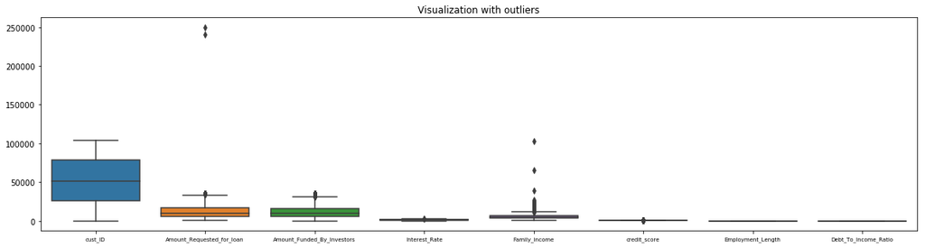

```python
plt.figure(figsize=(20,5))
plt.xticks(fontsize=7)
sns.boxplot(data=df3)
plt.title("Visualization with outliers")
plt.show()
```

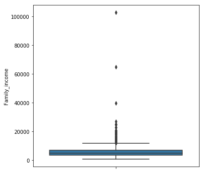

```python
plt.figure(figsize=(6,6))
sns.boxplot(y='Family_income', data=df3)
plt.show()
```

```python
Q1 = df3.Family_income.quantile(0.25)
Q3 = df3.Family_income.quantile(0.75)
IQR = Q3 - Q1
IQR
```

```
3416.33
```

```python
lower_limit = Q1-1.5*IQR
upper_limit = Q3+1.5*IQR
(lower_limit, upper_limit)
```

```
(-1707.495, 11957.825)
```

```python
df3[(df3.Family_income<lower_limit)| (df3.Family_income>upper_limit)]  #111 rows* 11 columns
```

|  | cust_ID | Amount_Requested_for_loan | Amount_Funded_By_Investors | Interest_Rate | Loan_duration | Family_income | credit_score | Employment_Length | owning_two_wheeler | age_band | Debt_To_Income_Ratio |
| --- | --- | --- | --- | --- | --- | --- | --- | --- | --- | --- | --- |
| 13 | 73179.0 | 29175.0 | 29175.00 | 21.0 | 60 | 12500.00 | 697 | 4.0 | no | 30-40 | 8.83 |
| 44 | 63404.0 | 23300.0 | 23275.00 | 2383.0 | 60 | 13666.67 | 662 | 9.0 | yes | 30-40 | 33.56 |
| 55 | 22150.0 | 6000.0 | 5950.00 | 10.0 | 36 | 15416.67 | 717 | 10.0 | no | 30-40 | 8.74 |
| 97 | 77151.0 | 20950.0 | 20950.00 | 158.0 | 36 | 12916.67 | 692 | 4.0 | no | 30-40 | 15.71 |
| 103 | 48798.0 | 14400.0 | 14400.00 | 662.0 | 36 | 12500.00 | 772 | 10.0 | no | 30-40 | 6.71 |
| 109 | 6521.0 | 24500.0 | 24450.00 | 1183.0 | 36 | 12500.00 | 812 | 10.0 | no | 30-40 | 13.42 |
| 111 | 89582.0 | 20000.0 | 20000.00 | 89.0 | 36 | 12083.33 | 682 | 1.0 | no | 30-40 | 10.79 |
| 177 | 46017.0 | 3500.0 | 3500.00 | 1581.0 | 36 | 18333.33 | 667 | 7.0 | no | 30-40 | 13.14 |
| 197 | 33155.0 | 14000.0 | 14000.00 | 1677.0 | 36 | 12083.33 | 672 | 1.0 | no | 30-40 | 9.67 |
| 215 | 8698.0 | 14725.0 | 14725.00 | 1941.0 | 36 | 18333.33 | 662 | 1.0 | no | 30-40 | 2.14 |
| 226 | 24464.0 | 35000.0 | 24868.47 | 1799.0 | 60 | 14000.00 | 717 | 10.0 | yes | 30-40 | 6.39 |
| 271 | 84897.0 | 35000.0 | 35000.00 | 2049.0 | 36 | 12333.33 | 702 | 10.0 | no | 30-40 | 20.82 |
| 272 | 14831.0 | 10000.0 | 10000.00 | 1186.0 | 36 | 13333.00 | 707 | 1.0 | yes | 30-40 | 11.15 |
| 290 | 41200.0 | 28000.0 | 27975.00 | 2167.0 | 60 | 14166.67 | 672 | 1.0 | yes | 30-40 | 13.07 |
| 360 | 52129.0 | 23000.0 | 23000.00 | 762.0 | 36 | 25000.00 | 812 | 10.0 | yes | 30-40 | 6.51 |
| 377 | 15083.0 | 25000.0 | 24950.00 | 2127.0 | 36 | 12500.00 | 672 | 10.0 | no | 30-40 | 8.33 |
| 387 | 30718.0 | 35000.0 | 33500.00 | 1349.0 | 60 | 15583.33 | 762 | 6.0 | no | 30-40 | 10.63 |
| 426 | 101800.0 | 25000.0 | 2125.00 | 1501.0 | 36 | 15416.67 | 697 | 2.0 | yes | 30-40 | 24.59 |
| 439 | 76933.0 | 6000.0 | 6000.00 | 89.0 | 36 | 12500.00 | 717 | 1.0 | no | 30-40 | 17.16 |
| 454 | 88420.0 | 27575.0 | 27575.00 | 1905.0 | 60 | 13125.00 | 672 | 6.0 | yes | 30-40 | 10.61 |
| 481 | 9839.0 | 20000.0 | 13175.00 | 788.0 | 60 | 19583.00 | 792 | 4.0 | no | 30-40 | 12.51 |
| 496 | 26886.0 | 12000.0 | 11975.00 | 1099.0 | 36 | 12083.33 | 722 | 3.0 | yes | 30-40 | 9.46 |
| 504 | 58595.0 | 20000.0 | 20000.00 | 89.0 | 36 | 17500.00 | 737 | 8.0 | yes | 30-40 | 3.18 |
| 507 | 18439.0 | 4500.0 | 4500.00 | 691.0 | 36 | 65000.00 | 727 | 7.0 | no | 30-40 | 0.58 |
| 515 | 18362.0 | 15000.0 | 14950.00 | 1632.0 | 60 | 14000.00 | 687 | 5.0 | no | 30-40 | 7.53 |
| 536 | 54201.0 | 7000.0 | 7000.00 | 1531.0 | 36 | 12208.33 | 687 | 10.0 | yes | 30-40 | 14.74 |
| 542 | 68406.0 | 20000.0 | 20000.00 | 1409.0 | 36 | 19583.33 | 712 | 7.0 | yes | 30-40 | 9.16 |
| 556 | 42555.0 | 8700.0 | 8700.00 | 1269.0 | 36 | 14166.67 | 677 | 1.0 | yes | 30-40 | 5.02 |
| 579 | 98634.0 | 20000.0 | 20000.00 | 603.0 | 36 | 14583.33 | 717 | 7.0 | no | 30-40 | 18.67 |
| 589 | 38826.0 | 29000.0 | 27884.92 | 1065.0 | 60 | 15000.00 | 747 | 10.0 | no | 30-40 | 3.90 |
| ... | ... | ... | ... | ... | ... | ... | ... | ... | ... | ... | ... |
| 1612 | 54487.0 | 33000.0 | 33000.00 | 762.0 | 36 | 102750.00 | 807 | 10.0 | yes | 45-55 | 0.26 |
| 1620 | 93022.0 | 32000.0 | 32000.00 | 1727.0 | 36 | 19166.67 | 707 | 5.0 | yes | 45-55 | 9.96 |
| 1653 | 70987.0 | 35000.0 | 35000.00 | 79.0 | 36 | 12083.33 | 792 | 10.0 | no | 45-55 | 20.70 |
| 1658 | 29200.0 | 18000.0 | 17950.00 | 1349.0 | 60 | 13333.33 | 742 | 1.0 | yes | 45-55 | 28.35 |
| 1713 | 30441.0 | 30000.0 | 22425.00 | 1059.0 | 36 | 22916.67 | 767 | 4.0 | no | 45-55 | 8.15 |
| 1719 | 40971.0 | 16000.0 | 16000.00 | 603.0 | 36 | 12916.67 | 792 | 10.0 | no | 45-55 | 6.07 |
| 1721 | 37228.0 | 33600.0 | 32058.53 | 203.0 | 60 | 20000.00 | 697 | 2.0 | no | 45-55 | 13.56 |
| 1725 | 72217.0 | 25000.0 | 25000.00 | 1311.0 | 36 | 14166.67 | 707 | 10.0 | no | 45-55 | 18.36 |
| 1750 | 13412.0 | 15000.0 | 13885.68 | 1793.0 | 60 | 12500.00 | 672 | 7.0 | yes | 45-55 | 8.06 |
| 1753 | 6466.0 | 24250.0 | 24144.61 | 1183.0 | 36 | 12000.00 | 757 | 1.0 | no | 45-55 | 4.79 |
| 1799 | 60695.0 | 12000.0 | 12000.00 | 1875.0 | 36 | 13333.33 | 667 | 5.0 | no | 45-55 | 27.32 |
| 1814 | 41267.0 | 35000.0 | 34975.00 | 79.0 | 36 | 18333.33 | 777 | 1.0 | yes | 45-55 | 1.59 |
| 1821 | 12788.0 | 16000.0 | 15900.00 | 1558.0 | 60 | 17500.00 | 702 | 5.0 | no | 45-55 | 5.21 |
| 1864 | 6039.0 | 24250.0 | 23811.24 | 1253.0 | 36 | 18750.00 | 727 | 10.0 | yes | 45-55 | 12.70 |
| 1878 | 42255.0 | 12000.0 | 12000.00 | 991.0 | 36 | 12500.00 | 707 | 9.0 | yes | 45-55 | 4.10 |
| 1904 | 78104.0 | 21000.0 | 21000.00 | 1849.0 | 60 | 16416.67 | 702 | 1.0 | yes | 45-55 | 21.73 |
| 1907 | 88361.0 | 12000.0 | 12000.00 | 662.0 | 36 | 12500.00 | 732 | 3.0 | no | 45-55 | 10.86 |
| 1915 | 41993.0 | 35000.0 | 35000.00 | 1758.0 | 36 | 13333.33 | 692 | 10.0 | no | 45-55 | 11.80 |
| 1919 | 49950.0 | 20000.0 | 20000.00 | 2278.0 | 60 | 12500.00 | 667 | 5.0 | no | 45-55 | 1.63 |
| 1935 | 85216.0 | 17500.0 | 17500.00 | 89.0 | 36 | 25000.00 | 732 | 6.0 | no | 45-55 | 10.94 |
| 1953 | 89438.0 | 35000.0 | 35000.00 | 1972.0 | 60 | 13333.33 | 692 | 3.0 | no | 45-55 | 22.38 |
| 1965 | 34411.0 | 10000.0 | 10000.00 | 603.0 | 36 | 13750.00 | 777 | 10.0 | no | 45-55 | 5.01 |
| 1991 | 102637.0 | 24000.0 | 9675.00 | 1715.0 | 36 | 18483.00 | 672 | 5.0 | no | 45-55 | 12.70 |
| 2021 | 66880.0 | 12000.0 | 12000.00 | 1311.0 | 36 | 13166.67 | 682 | 5.0 | no | 45-55 | 6.46 |
| 2025 | 82673.0 | 35000.0 | 35000.00 | 79.0 | 36 | 12083.33 | 772 | 10.0 | no | 45-55 | 20.27 |
| 2089 | 11868.0 | 25000.0 | 24975.00 | 1149.0 | 36 | 25000.00 | 727 | 7.0 | no | 45-55 | 11.78 |
| 2107 | 52353.0 | 35000.0 | 34950.00 | 2197.0 | 60 | 14166.67 | 692 | 3.0 | no | 45-55 | 19.32 |
| 2108 | 71550.0 | 35000.0 | 35000.00 | 1905.0 | 36 | 13750.00 | 737 | 10.0 | yes | 45-55 | 21.12 |
| 2155 | 88040.0 | 16000.0 | 15975.00 | 603.0 | 36 | 12750.00 | 807 | 10.0 | no | 45-55 | 9.20 |
| 2177 | 29595.0 | 30000.0 | 30000.00 | 2025.0 | 60 | 12500.00 | 697 | 5.0 | no | 45-55 | 10.46 |

111 rows × 11 columns